# Final Project Title

## 4.2 Functions for Checking

The following tabset contains a set of functions that work to quantify how helpful a guess word is. When working through this project, I asked the following main questions:

- “On how many days would a word give me X amount of green letters”
- “On how many days would a word give me X amount of yellow letters”
- “How does this word compare to other words?”

To begin this process, I created a set of functions that output the number of green and yellow letters a given word will obtain each day. These functions are shown in the following tabset, labeled with their purpose. By default, the final function will be open for viewing. This function outputs the number of both greens and yellows for each word in a dataframe format that is ready for plotting.

**Greens**

This function checks how many Green letters you will receive.

Formula: Check if Letter1 = Letter1, output 1 or 0 to represent yes or no. After doing this for each letter, it adds up the 1s and creates a column for greens

```r
check_green <- function(df, word) {

  df |>
    mutate(g1 = if_else(str_sub(answer, 1, 1) == str_sub(word, 1, 1), 1, 0),
           g2 = if_else(str_sub(answer, 2, 2) == str_sub(word, 2, 2), 1, 0),
           g3 = if_else(str_sub(answer, 3, 3) == str_sub(word, 3, 3), 1, 0),
           g4 = if_else(str_sub(answer, 4, 4) == str_sub(word, 4, 4), 1, 0),
           g5 = if_else(str_sub(answer, 5, 5) == str_sub(word, 5, 5), 1, 0)) |>
    mutate(greens = rowSums(across(7:11)))

}

# Example (first 10 rows)
kable(check_green(answers1, "SEVEN")[1:10,])
```

| Date | puzzle_num | answer | year | month | day | g1 | g2 | g3 | g4 | g5 | greens |
| --- | --- | --- | --- | --- | --- | --- | --- | --- | --- | --- | --- |
| April 08, 2026 | 1754 | INLET | 2026 | 4 | 8 | 0 | 0 | 0 | 1 | 0 | 1 |
| April 07, 2026 | 1753 | DENSE | 2026 | 4 | 7 | 0 | 1 | 0 | 0 | 0 | 1 |
| April 06, 2026 | 1752 | SWORN | 2026 | 4 | 6 | 1 | 0 | 0 | 0 | 1 | 2 |
| April 05, 2026 | 1751 | ENVOY | 2026 | 4 | 5 | 0 | 0 | 1 | 0 | 0 | 1 |
| April 04, 2026 | 1750 | SANDY | 2026 | 4 | 4 | 1 | 0 | 0 | 0 | 0 | 1 |
| April 03, 2026 | 1749 | SINGE | 2026 | 4 | 3 | 1 | 0 | 0 | 0 | 0 | 1 |
| April 02, 2026 | 1748 | SOBER | 2026 | 4 | 2 | 1 | 0 | 0 | 1 | 0 | 2 |
| April 01, 2026 | 1747 | FIZZY | 2026 | 4 | 1 | 0 | 0 | 0 | 0 | 0 | 0 |
| March 31, 2026 | 1746 | SWAMP | 2026 | 3 | 31 | 1 | 0 | 0 | 0 | 0 | 1 |
| March 30, 2026 | 1745 | COMET | 2026 | 3 | 30 | 0 | 0 | 0 | 1 | 0 | 1 |

**Yellows (Forumla)**

This function creates a formula for yellows. `str_split` and `paste0` work to change the word into regular expressions.

example: - SEVEN becomes a vector of S{1} E{1} V{1} E{1} N{1}. - `str_remove` then inputs these one by one and outputs the letters remaining afterwards.

```r
yellow_formula <- function(answer, word) {

  p_letters <- paste0(unlist(str_split(word, "")), "{1}")

  remaining <-
    str_remove(
      str_remove(
        str_remove(
          str_remove(
            str_remove(
              answer, p_letters[1]), p_letters[2]), p_letters[3]), p_letters[4]), p_letters[5])

}
```

**Yellows & Greens**

This function builds on the previous by counting the remaining letters and subtracting them from 5. This will output the number of letters that the input word removed. Finally, the number of greens is subtracted from this number to output the number of yellows

```r
check_yellowgreen <- function(df, word) {

  stopifnot(is.data.frame(df))      # checks that df is a dataframe
  stopifnot(str_length(word) == 5)   # checks that word input is 5 letters

  df2 <- check_green(df, word)

  df3 <- df2 |>
    select(-g1, -g2, -g3, -g4, -g5) |>
    mutate(yellows = (5 - str_length(yellow_formula(df$answer, word))) - greens)

  return(df3)
}

# Test
check_yellowgreen(answers1, "CLEAR")
```

| Date | puzzle_num | answer | year | month | day | greens | yellows |
| --- | --- | --- | --- | --- | --- | --- | --- |
| April 08, 2026 | 1754 | INLET | 2026 | 4 | 8 | 0 | 2 |
| April 07, 2026 | 1753 | DENSE | 2026 | 4 | 7 | 0 | 1 |
| April 06, 2026 | 1752 | SWORN | 2026 | 4 | 6 | 0 | 1 |
| April 05, 2026 | 1751 | ENVOY | 2026 | 4 | 5 | 0 | 1 |
| April 04, 2026 | 1750 | SANDY | 2026 | 4 | 4 | 0 | 1 |
| April 03, 2026 | 1749 | SINGE | 2026 | 4 | 3 | 0 | 1 |
| April 02, 2026 | 1748 | SOBER | 2026 | 4 | 2 | 1 | 1 |
| April 01, 2026 | 1747 | FIZZY | 2026 | 4 | 1 | 0 | 0 |
| March 31, 2026 | 1746 | SWAMP | 2026 | 3 | 31 | 0 | 1 |
| March 30, 2026 | 1745 | COMET | 2026 | 3 | 30 | 1 | 1 |

[output cut: 1745 more lines]

## 4.3 Functions for Plotting

The next step in this process was to create functions for plotting the number of yellow and green letters that the previous functions obtained. The following tabset also contains three functions, ordered similarly to the previous tabset. The default open tab contains the function for plotting both green and yellow letters side by side.

**Greens**

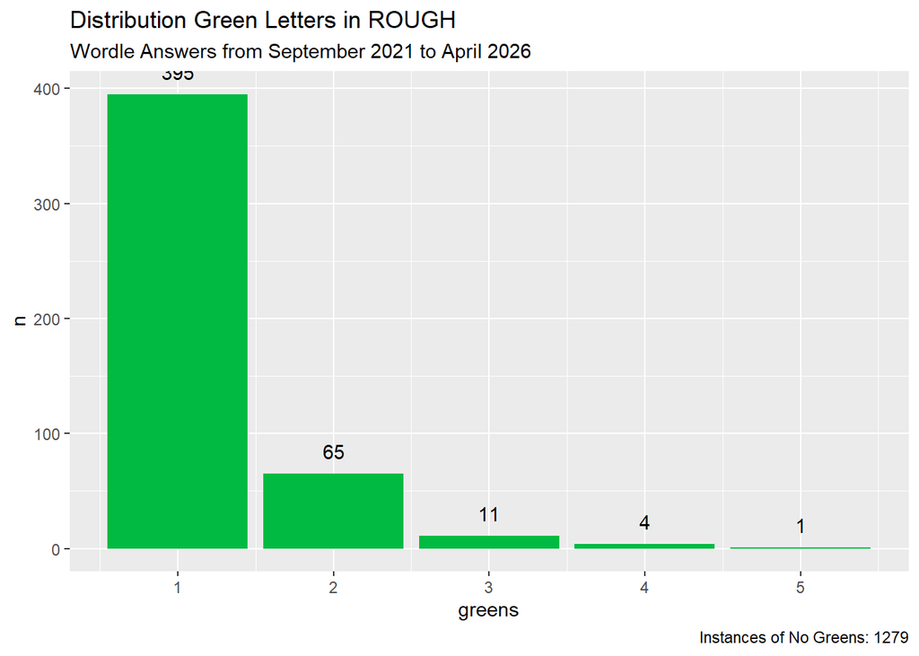

```r
plot_green <- function(df, word) {

  df2 <- check_yellowgreen(df, word)

  df3 <- df2 |>
           count(greens)

  df3 |>
    filter(greens != 0) |>
    ggplot(aes(greens, n)) +
    geom_col(fill = "#00BA42") +
    geom_text(aes(label = n), vjust = -1) +
    scale_x_continuous(breaks = c(1,2,3,4,5)) +
    labs(title = paste0("Distribution Green Letters in ", word),
         subtitle = "Wordle Answers from September 2021 to April 2026",
         caption = paste0("Instances of No Greens: ", sum(df2$greens == 0)))

}

# Test
plot_green(answers1, "ROUGH")
```

**Yellows**

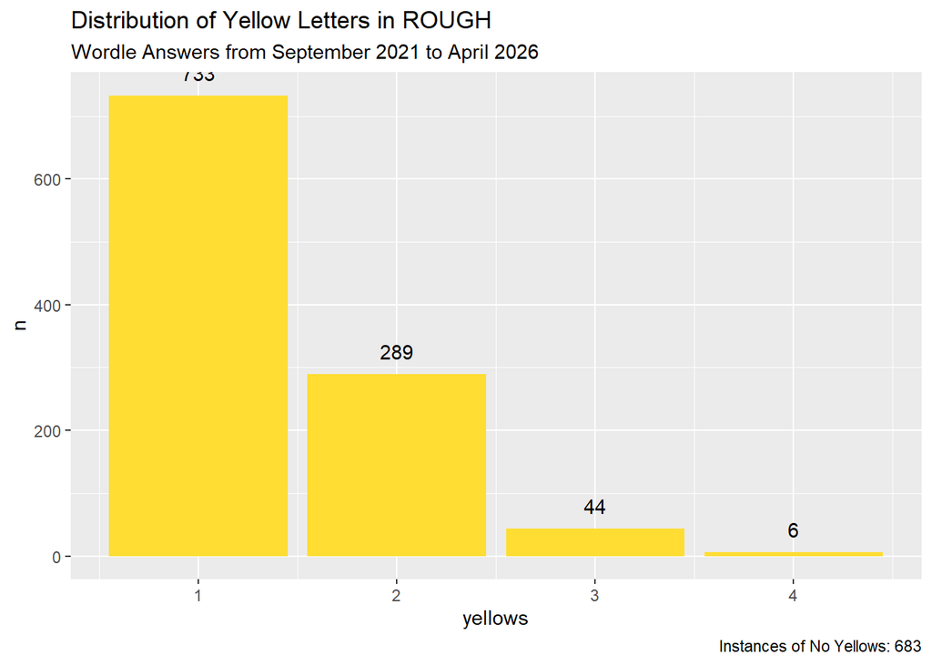

```r
plot_yellow <- function(df, word) {

  df2 <- check_yellowgreen(df, word)

  df3 <- df2 |>
           count(yellows)

  df3 |>
    filter(yellows != 0) |>
    ggplot(aes(yellows, n)) +
    geom_col(fill = "#FFDD33") +
    geom_text(aes(label = n), vjust = -1) +
    scale_x_continuous(breaks = c(1,2,3,4,5)) +
    labs(title = paste0("Distribution of Yellow Letters in ", word),
         subtitle = "Wordle Answers from September 2021 to April 2026",
         caption = paste0("Instances of No Yellows: ", sum(df2$yellows == 0)))


}

# Test
plot_yellow(answers1, "ROUGH")
```

**Both**

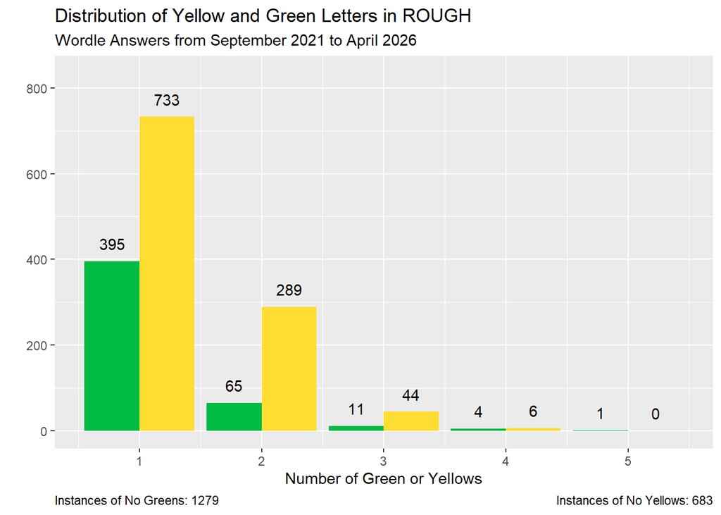

```r
plot_yellowgreen <- function(df, word) {

  stopifnot(is.data.frame(df))
  stopifnot(str_length(word) == 5)

  df2 <- check_yellowgreen(df, word)

  dfg <- df2 |>
    count(greens) |>
    complete(greens = 0:5, fill = list(n = 0)) |>
    rename(count = greens) |>
    mutate(color = "greens") |>
    filter(count != 0)

  dfy <- df2 |>
    count(yellows) |>
    complete(yellows = 0:5, fill = list(n = 0)) |>
    rename(count = yellows) |>
    mutate(color = "yellows") |>
    filter(count != 0)

  df3 <- full_join(dfg, dfy)

  df3 |>
    ggplot(aes(count, n, fill = color)) +
    geom_col(position = "dodge") +
    scale_fill_manual(values = c("greens" = "#00BA42", "yellows" = "#FFDD33")) +
    geom_text_repel(aes(label = n),
                    vjust = -1,
                    ylim = c(0, NA),
                    position = position_dodge(width = 0.9)) +
    #scale_color_manual(values = c("greens" = "#00BA42", "yellows" = "#FFDD33")) +
    scale_x_continuous(breaks = c(1,2,3,4,5)) +
    ylim(0, max(df3$n) + 100) +
    labs(title = paste0("Distribution of Yellow and Green Letters in ", word),
         subtitle = "Wordle Answers from September 2021 to April 2026",
         caption = c(paste0("Instances of No Yellows: ", sum(df2$yellows == 0)),
                     paste0("Instances of No Greens: ", sum(df2$greens == 0))),
         x = "Number of Green or Yellows",
         y = "") +
    theme(legend.position = "none",
          plot.caption = element_text(hjust = c(1, 0)))

}

# Test
plot_yellowgreen(answers1, "ROUGH")
```

## 4.4 Functions for Ranking

Finally, this third tabset contains functions that aim to answer my third question: “How does this word compare to other words?” Utilizing the previous functions that were designed for outputting plottable tables, these two functions output a simple vector containing the total number of green or yellow letters achieved by a single word. By using these functions, we can apply a numerical value to any five letter word and compare its value against others.

**All Greens**

```r
all_green <- function(df, word) {

  df1 <- check_yellowgreen(df, word)

  return(sum(df1$greens))
}

# Test
all_green(answers1, "SEVEN")
```

```
[1] 807
```

**All Yellows**

```r
all_yellow <- function(df, word) {

  df1 <- check_yellowgreen(df, word)

  return(sum(df1$yellows))
}

# Test
all_yellow(answers1, "SEVEN")
```

```
[1] 1120
```

## 4.5 Wrangling Secondary Dataset

```r
allwords <- read_csv("data/english_words.csv")

wordrankings <- allwords |>
  mutate(X1 = str_to_upper(X1)) |>
  rowwise() |>
  mutate(totalgreen = all_green(answers1, X1),
         totalyellow = all_yellow(answers1, X1)) |>
  ungroup()
```

```r
wordrankings2 <- wordrankings |>
  rename(guess = X1) |>
  mutate(greenrank = paste0("#", min_rank(-totalgreen)),
         yellowrank = paste0("#", min_rank(-totalyellow)))
```

# 5 Analysis

## 5.1 Rankings

```r
wordrankings2 |>
  slice_max(totalgreen, n = 10)
```

| guess | totalgreen | totalyellow | greenrank | yellowrank |
| --- | --- | --- | --- | --- |
| SLATE | 1125 | 1883 | #1 | #548 |
| SHALE | 1112 | 1670 | #2 | #1089 |
| SHARE | 1112 | 1821 | #2 | #679 |
| CRANE | 1100 | 1831 | #4 | #653 |
| SOUSE | 1087 | 1094 | #5 | #2706 |
| SHONE | 1075 | 1454 | #6 | #1836 |
| CEASE | 1071 | 1373 | #7 | #2088 |
| SAUCE | 1068 | 1592 | #8 | #1333 |
| SHINE | 1067 | 1418 | #9 | #1949 |
| SNARE | 1066 | 1980 | #10 | #347 |

```r
wordrankings2 |>
  slice_max(totalyellow, n = 10)
```

| guess | totalgreen | totalyellow | greenrank | yellowrank |
| --- | --- | --- | --- | --- |
| OPERA | 373 | 2585 | #3017 | #1 |
| ASTER | 588 | 2571 | #2003 | #2 |
| EARLS | 551 | 2569 | #2289 | #3 |
| RATES | 631 | 2528 | #1674 | #4 |
| ALERT | 716 | 2482 | #994 | #5 |
| ALTER | 721 | 2477 | #952 | #6 |
| EARNS | 571 | 2475 | #2162 | #7 |
| REALS | 659 | 2461 | #1420 | #8 |
| TEARS | 705 | 2454 | #1069 | #9 |
| ACRES | 519 | 2447 | #2473 | #10 |

## 5.2 Analyzing “Slate” and “Audio”

As shown through the ranking tables, the word “slate” stands out as the alleged best guess for green letters in Wordle. This comes without suprise, even Wordle’s own “Wordle Bot” suggests using the word “slate” as a starting point.

Another standoutword is the popular “audio”. This word is widely popular for its use of four vowels, helping to narrow down words by attacking a vital structural mechanism. In my opinion, I believe this word is a waste due to its lack of consonants, which, in my opinion, hold more value than vowels.

Using the previously created functions, we can actually assess how the word “audio” performs and how it shapes up against others such as “slate”. The following plots shows the distribution of green and yellow letters for the words “slate” (left) and “audio” (right).

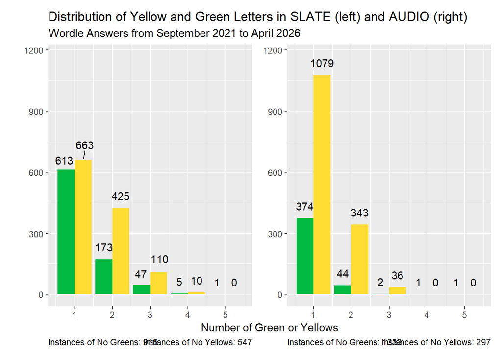

```r
p1 <- plot_yellowgreen(answers1, "SLATE") +
  labs(title = "Distribution of Yellow and Green Letters in SLATE (left) and AUDIO (right)")

p2 <- plot_yellowgreen(answers1, "AUDIO") +
  labs(title = "",
       subtitle = "")

p1 + p2 +
  plot_layout(axis_titles = "collect") & ylim(0, 1170)
```

These plots present the large gap between these two words, apparent in the leftmost category, instances of one produced green or yellow letter. While slate performs seemingly even in green and yellow letters, audio produces a much higher instance of yellow letters. This lines up with its usage for assessing vowels by showing the consistent usefulness of the word, even if actual placement is not discovered.

Additionally, we can compare the two words rankings. The following table shows the rankings of both “audio” and “slate”.

```r
wordrankings2 |>
    filter(guess == "SLATE" | guess == "AUDIO")
```

| guess | totalgreen | totalyellow | greenrank | yellowrank |
| --- | --- | --- | --- | --- |
| AUDIO | 477 | 1873 | #2703 | #566 |
| SLATE | 1125 | 1883 | #1 | #548 |

Suprisingly, both are quite similar in their yellow rank, with “slate” just barely surpassing “audio” with only 10 more achieved yellow letters, placing the word 18 ranks higher. At first this seems shocking, since the previous plots depict audio as a guess that produces a huge amount of yellow letters, however, slate outperforms audio in the two-letter and three-letter categories, both of which hold higher weight for counting overall yellow letters achieved. Through this we can conclude that despite audio’s clear ability to assess vowel usage, its performance does not hold up against other guesses.

## 5.3 Over Time

One final way to analyze wordle guesses can be to see their effectiveness over time. The following plot shows the average amount of yellow and green letters achieved by the top ranked word “slate” by month in 2025.

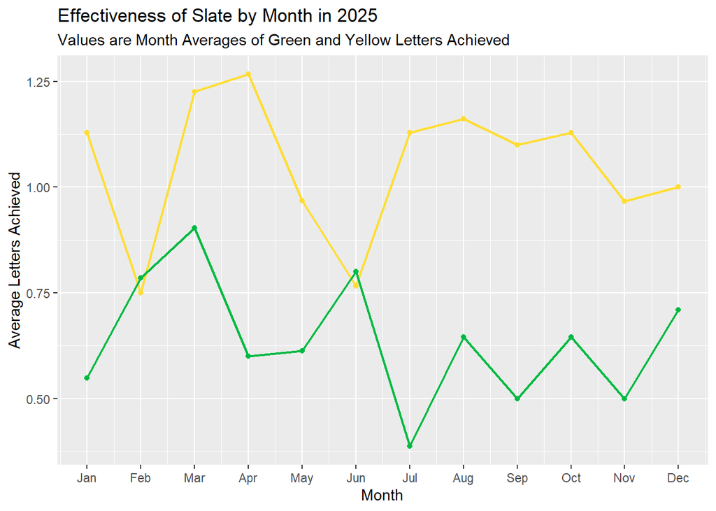

```r
slateframe <- check_yellowgreen(answers1, "SLATE") |>
  filter(year == 2025) |>
  group_by(month) |>
  mutate(g_avg = mean(greens),
         y_avg = mean(yellows))

slateframe |>
  ggplot(aes(x = month)) +
  geom_line(aes(y = y_avg), color = "#FFDD33", linewidth = 0.8) +
  geom_point(aes(y = y_avg), color = "#FFDD33") +
  geom_line(aes(y = g_avg), color = "#00BA42", linewidth = 0.8) +
  geom_point(aes(y = g_avg), color = "#00BA42") +
  scale_x_continuous(breaks = 1:12, labels = month.abb) +
  labs(title = "Effectiveness of Slate by Month in 2025",
       subtitle = "Values are Month Averages of Green and Yellow Letters Achieved",
       x = "Month",
       y = "Average Letters Achieved")
```

# 6 Reflection

- Functions may be convoluted, possible to shorten?
- Shiny App: permanent link
- Rank Dataset: GitHub user good enough? concern with citation or reliability
- Time Analysis: could use work and could be implemented into shiny
- Oversight for Intersection of Green and Yellows (1G+3Y vs 1G+0Y)